# Variables checking

Mathilde Le Vu

2022-05-11

# Opening the data file

```r
bevn <- read.csv2(here("data", "birth_iem.csv"))
```

# Checking each variable has the correct format and content

## Statistikjahr und Ereignisjahr = statistical year and year of birth

Expected Ereignisjahr: from 1987 to 2020, no missing

```r
summary(bevn$Statistikjahr)
```

```
##    Min. 1st Qu.  Median    Mean 3rd Qu.    Max.
##    1987    1995    2005    2004    2013    2022
```

```r
table(bevn$Statistikjahr, useNA="always")
```

```
##
##   1987   1988   1989   1990   1991   1992   1993   1994   1995   1996   1997
##  78132  82054  83032  86125  88786  89285  85849  84842  84059  84738  82327
##   1998   1999   2000   2001   2002   2003   2004   2005   2006   2007   2008
##  80944  80145  80309  75368  75258  74928  76633  81712  84484  86446  88014
##   2009   2010   2011   2012   2013   2014   2015   2016   2017   2018   2019
##  89865  91307  92123  93497  94820  97794  99200 100219  99768  99945  98536
##   2020   2021   2022   <NA>
##  97436   4725    280      0
```

```r
round(prop.table(table(bevn$Statistikjahr, useNA="always"))*100,2)
```

```
##
## 1987 1988 1989 1990 1991 1992 1993 1994 1995 1996 1997 1998 1999 2000 2001 2002
## 2.63 2.76 2.79 2.90 2.99 3.00 2.89 2.85 2.83 2.85 2.77 2.72 2.70 2.70 2.54 2.53
## 2003 2004 2005 2006 2007 2008 2009 2010 2011 2012 2013 2014 2015 2016 2017 2018
## 2.52 2.58 2.75 2.84 2.91 2.96 3.02 3.07 3.10 3.14 3.19 3.29 3.34 3.37 3.36 3.36
## 2019 2020 2021 2022 <NA>
## 3.31 3.28 0.16 0.01 0.00
```

```r
summary(bevn$Ereignisjahr)
```

```
##    Min. 1st Qu.  Median    Mean 3rd Qu.    Max.
##    1987    1995    2005    2004    2013    2020
```

```r
table(bevn$Ereignisjahr, useNA="always")
```

```
##
##   1987   1988   1989   1990   1991   1992   1993   1994   1995   1996   1997
##  78140  82062  83040  86123  88780  89290  85849  84847  84057  84758  82358
##   1998   1999   2000   2001   2002   2003   2004   2005   2006   2007   2008
##  80913  80170  80538  75827  76253  76666  79339  83089  84608  85893  88298
##   2009   2010   2011   2012   2013   2014   2015   2016   2017   2018   2019
##  90097  92791  92324  94376  95010  97496  98688 100353  99050  99192  97042
##   2020   <NA>
##  95668      0
```

```r
round(prop.table(table(bevn$Ereignisjahr, useNA="always"))*100,2)
```

```
##
## 1987 1988 1989 1990 1991 1992 1993 1994 1995 1996 1997 1998 1999 2000 2001 2002
## 2.63 2.76 2.79 2.90 2.99 3.00 2.89 2.85 2.83 2.85 2.77 2.72 2.70 2.71 2.55 2.56
## 2003 2004 2005 2006 2007 2008 2009 2010 2011 2012 2013 2014 2015 2016 2017 2018
## 2.58 2.67 2.79 2.85 2.89 2.97 3.03 3.12 3.11 3.17 3.20 3.28 3.32 3.38 3.33 3.34
## 2019 2020 <NA>
## 3.26 3.22 0.00
```

## Ereignismonat = month of birth

Expected: 1-12

```r
summary(bevn$Ereignismonat)
```

```
##    Min. 1st Qu.  Median    Mean 3rd Qu.    Max.
##   1.000   4.000   7.000   6.514   9.000  12.000
```

```r
table(bevn$Ereignismonat, useNA="always")
```

```
##
##      1      2      3      4      5      6      7      8      9     10     11
## 246163 228298 248783 243643 253913 250103 263998 256356 258235 248375 234808
##     12   <NA>
## 240310      0
```

```r
round(prop.table(table(bevn$Ereignismonat, useNA="always"))*100,2)
```

```
##
##    1    2    3    4    5    6    7    8    9   10   11   12 <NA>
## 8.28 7.68 8.37 8.20 8.54 8.41 8.88 8.62 8.69 8.35 7.90 8.08 0.00
```

## Mutter und Vater: Alter in erfüllten Jahren: Age mother/father (fullfilled years)

expected? 10-65 for women and 10-90+ for men?

```r
summary(bevn$Mutter..Alter.in.erfüllten.Jahren)
```

```
##    Min. 1st Qu.  Median    Mean 3rd Qu.    Max.
##    9.00   27.00   30.00   30.34   34.00   67.00
```

```r
summary(bevn$Vater..Alter.in.erfüllten.Jahren)
```

```
##    Min. 1st Qu.  Median    Mean 3rd Qu.    Max.    NA's
##   13.00   29.00   33.00   33.48   37.00   93.00  178075
```

## Kind: Geschlecht = sex of the neonate

1=male, 2=female

```r
table(bevn$Kind..Geschlecht, useNA="always")
```

```
##
##       F       M    <NA>
## 1446063 1526922       0
```

```r
round(prop.table(table(bevn$Kind..Geschlecht, useNA="always"))*100,2)
```

```
##
##     F     M  <NA>
## 48.64 51.36  0.00
```

## Kind: Gestationsalter = gestational age

in Tagen days, missing=empty, only since 2006  
Expected: 100-308?  
Checking that its available since 2006

```r
summary(bevn$Kind..Gestationsalter.in.Tagen)
```

```
##    Min. 1st Qu.  Median    Mean 3rd Qu.    Max.    NA's
##   112.0   270.0   277.0   274.5   283.0   321.0 1780447
```

```r
##GA in weeks
bevn$Kind..Gestationsalter.in.Tagen <- as.numeric(bevn$Kind..Gestationsalter.in.Tagen)
bevn$GA_weeks <- bevn$Kind..Gestationsalter.in.Tagen / 7
summary(bevn$GA_weeks)
```

```
##    Min. 1st Qu.  Median    Mean 3rd Qu.    Max.    NA's
##    16.0    38.6    39.6    39.2    40.4    45.9 1780447
```

```r
tapply(bevn$GA_weeks, bevn$Ereignisjahr, summary)
```

```
## $`1987`
##    Min. 1st Qu.  Median    Mean 3rd Qu.    Max.    NA's
##      NA      NA      NA     NaN      NA      NA   78140
##
## $`1988`
##    Min. 1st Qu.  Median    Mean 3rd Qu.    Max.    NA's
##      NA      NA      NA     NaN      NA      NA   82062
##
## $`1989`
##    Min. 1st Qu.  Median    Mean 3rd Qu.    Max.    NA's
##      NA      NA      NA     NaN      NA      NA   83040
##
## $`1990`
##    Min. 1st Qu.  Median    Mean 3rd Qu.    Max.    NA's
##      NA      NA      NA     NaN      NA      NA   86123
##
## $`1991`
##    Min. 1st Qu.  Median    Mean 3rd Qu.    Max.    NA's
##      NA      NA      NA     NaN      NA      NA   88780
##
## $`1992`
##    Min. 1st Qu.  Median    Mean 3rd Qu.    Max.    NA's
##      NA      NA      NA     NaN      NA      NA   89290
##
## $`1993`
##    Min. 1st Qu.  Median    Mean 3rd Qu.    Max.    NA's
##      NA      NA      NA     NaN      NA      NA   85849
##
## $`1994`
##    Min. 1st Qu.  Median    Mean 3rd Qu.    Max.    NA's
##      NA      NA      NA     NaN      NA      NA   84847
##
## $`1995`
##    Min. 1st Qu.  Median    Mean 3rd Qu.    Max.    NA's
##      NA      NA      NA     NaN      NA      NA   84057
##
## $`1996`
##    Min. 1st Qu.  Median    Mean 3rd Qu.    Max.    NA's
##      NA      NA      NA     NaN      NA      NA   84758
##
```

[output cut: 80 more lines]

```
## $`2017`
##    Min. 1st Qu.  Median    Mean 3rd Qu.    Max.    NA's
##   16.86   38.57   39.57   39.24   40.43   45.00    9180
##
## $`2018`
##    Min. 1st Qu.  Median    Mean 3rd Qu.    Max.    NA's
##   16.00   38.57   39.57   39.24   40.43   44.86    8705
##
## $`2019`
##    Min. 1st Qu.  Median    Mean 3rd Qu.    Max.    NA's
##   16.00   38.57   39.57   39.28   40.43   45.29    8075
##
## $`2020`
##    Min. 1st Qu.  Median    Mean 3rd Qu.    Max.    NA's
##   16.00   38.57   39.57   39.28   40.43   44.57    7234
```

```r
#calculating mean by year
 group_mean <- aggregate(GA_weeks ~ Ereignisjahr, data = bevn, mean) # Equivalent works
 group_mean
```

```
##    Ereignisjahr GA_weeks
## 1          2003 31.21429
## 2          2005 38.55102
## 3          2006 39.19232
## 4          2007 39.17533
## 5          2008 39.13547
## 6          2009 39.17110
## 7          2010 39.20557
## 8          2011 39.21594
## 9          2012 39.18114
## 10         2013 39.20956
## 11         2014 39.22258
## 12         2015 39.22680
## 13         2016 39.21286
## 14         2017 39.24373
## 15         2018 39.23977
## 16         2019 39.27626
## 17         2020 39.27568
```

## Geburtsort = place of birth (hospital or at home)

Only available until 1997 (ca. 98% in hospitals)  
Coding  
1- im Spital à l’hôpital 1969-1997  
2- zu Hause à la maison 1969-1997  
3- anderer Ort autre lieu 1987-1997  
4- Ort unbekannt lieu inconnu 1987-1997  
9- Angabe fehlt pas d’indication 1987-1997

```r
table(bevn$Geburtsort, useNA = "always")
```

```
##
##       1       2       3       4       9    <NA>
##  916896    9745    1210     512     884 2043738
```

```r
round(prop.table(table(bevn$Geburtsort, useNA="always"))*100,2)
```

```
##
##     1     2     3     4     9  <NA>
## 30.84  0.33  0.04  0.02  0.03 68.74
```

Only available until 1997: okay

## Geburtsstaat = State and world region of birth

See separate codebook  
Expected: 8100-8703

```r
#checking min and max values (should be 8100 and 8703)
  summary(bevn$Geburtsstaat)
```

```
##    Min. 1st Qu.  Median    Mean 3rd Qu.    Max.    NA's
##    8100    8100    8100    8111    8100    8999       1
```

```r
#8999 doesnt correspond to anything in the codebook but probably NA
  table(bevn$Geburtsstaat, useNA = "always")
```

```
##
##    8100    8201    8202    8204    8205    8206    8207    8211    8212    8214
## 2824645      36       4    1853      73     571   19909     375   32741     648
##    8215    8216    8217    8218    8220    8222    8223    8224    8226    8227
##    7957     345      62    8549      15     645     300      39     177    1542
##    8228    8229    8230    8231    8232    8233    8234    8236    8238    8239
##     543    3830     240     460     133       1    1124    3870       7    1193
##    8240    8242    8243    8244    8248    8250    8251    8252    8254    8255
##     255      58      70     311     501     262      71     116      29     165
##    8256    8260    8261    8262    8263    8264    8265    8266    8301    8302
##     263      22      18       8      11     348     110      18       2      66
##    8303    8304    8305    8307    8308    8309    8310    8311    8312    8313
##       1     234      17      12      11      11      86       7      27      75
##    8314    8315    8317    8319    8320    8322    8323    8324    8325    8326
##       4      48     109      13     207       8      50       2       2      30
```

[output cut: 26 more lines]

```r
#assign NA to values=8999
  bevn$Geburtsstaat[bevn$Geburtsstaat ==8999] = NA

# categorizing state of birth in : Switzerland or Outside of Switzerland
  bevn$Geburtsstaat_cat1 <- cut(bevn$Geburtsstaat, breaks=c(8000, 8100, 10000), include.lowest=TRUE, labels=c("Switzerland", "Outside Switzerland"))
  table(bevn$Geburtsstaat_cat1, useNA = "always")
```

```
##
##         Switzerland Outside Switzerland                <NA>
##             2824645              148335                   5
```

```r
  round(prop.table(table(bevn$Geburtsstaat_cat1, useNA="always"))*100,2)
```

```
##
##         Switzerland Outside Switzerland                <NA>
##               95.01                4.99                0.00
```

```r
#categorizing state of birth in : Switzerland, Europe, Africa, Americas, Asia, Oceania, other
  bevn$Geburtsstaat_cat2 <- cut(bevn$Geburtsstaat, breaks=c(8000, 8100, 8280, 8384, 8486, 8601, 8685, 10000), include.lowest=TRUE, labels=c("Switzerland", "Europe - excl Switz", "Africa", "Americas", "Asia", "Oceania", "Other"))
table(bevn$Geburtsstaat_cat2, useNA = "always")
```

```
##
##         Switzerland Europe - excl Switz              Africa            Americas
##             2824645               89878                4803               30639
##                Asia             Oceania               Other                <NA>
##               21840                1175                   0                   5
```

```r
round(prop.table(table(bevn$Geburtsstaat_cat2, useNA="always"))*100,2)
```

```
##
##         Switzerland Europe - excl Switz              Africa            Americas
##               95.01                3.02                0.16                1.03
##                Asia             Oceania               Other                <NA>
##                0.73                0.04                0.00                0.00
```

```r
#categorizing state of birth in : Switzerland, different parts of Europe, other
bevn$Geburtsstaat_cat3 <- as.factor(ifelse(bevn$Geburtsstaat == 8100, 'Switz',
                                    ifelse(bevn$Geburtsstaat == 8207 | bevn$Geburtsstaat == 8208 | bevn$Geburtsstaat == 8209 | bevn$Geburtsstaat == 8222 | bevn$Geburtsstaat == 8229 | bevn$Geburtsstaat == 8230 | bevn$Geburtsstaat == 8238 | bevn$Geburtsstaat == 8243 | bevn$Geburtsstaat == 8244,  'Central Europe',
                                    ifelse (bevn$Geburtsstaat == 8201 | bevn$Geburtsstaat == 8205 | bevn$Geburtsstaat ==8220 | bevn$Geburtsstaat == 8232 | bevn$Geburtsstaat == 82880 | (bevn$Geburtsstaat > 8247 & bevn$Geburtsstaat< 8258) , 'SE Europe',
                                    ifelse(bevn$Geburtsstaat==8202 | bevn$Geburtsstaat== 8213 | bevn$Geburtsstaat==8231 |bevn$Geburtsstaat== 8236, 'SW Europe',
                                    ifelse(bevn$Geburtsstaat==8204 | bevn$Geburtsstaat==8212 |bevn$Geburtsstaat==8215|bevn$Geburtsstaat==8216|bevn$Geburtsstaat==8223|bevn$Geburtsstaat==8225|bevn$Geburtsstaat==8226|bevn$Geburtsstaat==8227|bevn$Geburtsstaat==8270|bevn$Geburtsstaat==8271|bevn$Geburtsstaat==8272|bevn$Geburtsstaat==8275, 'Western Europe',
                                 ifelse(bevn$Geburtsstaat==8206|bevn$Geburtsstaat==8210|bevn$Geburtsstaat==8211|bevn$Geburtsstaat==8217|bevn$Geburtsstaat==8228|bevn$Geburtsstaat==8234|bevn$Geburtsstaat==8273|bevn$Geburtsstaat==8274,'Northern Europe',
                                ifelse(bevn$Geburtsstaat==8214|bevn$Geburtsstaat==8218|bevn$Geburtsstaat==8224|bevn$Geburtsstaat==8233|bevn$Geburtsstaat==8239|bevn$Geburtsstaat==8241|bevn$Geburtsstaat==8242, 'Southern Europe',
                                ifelse(bevn$Geburtsstaat==8235|bevn$Geburtsstaat==8572|bevn$Geburtsstaat==8573|bevn$Geburtsstaat==8574|bevn$Geburtsstaat==8576|bevn$Geburtsstaat==8577|bevn$Geburtsstaat==8578 | (bevn$Geburtsstaat > 8259 & bevn$Geburtsstaat < 8267), 'Eastern Europe','other')))))))))

round(prop.table(table(bevn$Geburtsstaat_cat3, useNA="always"))*100,2)
```

```
##
##  Central Europe  Eastern Europe Northern Europe           other       SE Europe
##            0.84            0.02            0.09            1.97            0.06
## Southern Europe       SW Europe           Switz  Western Europe            <NA>
##            0.35            0.15           95.01            1.51            0.00
```

4 attritbuted to 8999: doesnt correspond to any country in the codebook -> attributed to NA  
95% of total births took place in Switzerland.

## Art der Geburt = number of babies

1=singleton, 2=twins, 3=triplets, …, 6=sextuplets and more  
Expected: 1-6

```r
table(bevn$Art.der.Geburt, useNA="always")
```

```
##
##       1       2       3       4       5    <NA>
## 2880121   89903    2799     152      10       0
```

```r
round(prop.table(table(bevn$Art.der.Geburt, useNA="always"))*100,2)
```

```
##
##     1     2     3     4     5  <NA>
## 96.88  3.02  0.09  0.01  0.00  0.00
```

## Anzahl Knaben and Anzahl Mädchen = if multiple birth, number of boys and girls

Expected: 0-5

```r
table(bevn$Anzahl.Knaben, useNA = "always")
```

```
##
##       0       1       2       3       4    <NA>
##   29778   31812   30660     610       4 2880121
```

```r
table(bevn$Anzahl.Mädchen, useNA = "always")
```

```
##
##       0       1       2       3       4    <NA>
##   30337   31761   30188     566      12 2880121
```

## Kind: Grösse in Zentimeter = length at birth (cm), missing=99

Expected: 10-60? And 99 for missing

```r
summary(bevn$Kind..Grösse.in.Zentimeter)
```

```
##    Min. 1st Qu.  Median    Mean 3rd Qu.    Max.    NA's
##     0.0    48.0    50.0    51.1    51.0    99.0       3
```

```r
#assign birthlength=99 to NA
bevn$Kind..Grösse.in.Zentimeter[bevn$Kind..Grösse.in.Zentimeter ==99 | bevn$Kind..Grösse.in.Zentimeter==0] = NA
summary(bevn$Kind..Grösse.in.Zentimeter)
```

```
##    Min. 1st Qu.  Median    Mean 3rd Qu.    Max.    NA's
##    1.00   48.00   50.00   49.33   51.00   64.00  151516
```

```r
table(bevn$Kind..Grösse.in.Zentimeter, useNA = "always")
```

```
##
##      1      5      8      9     10     11     12     13     14     15     16
##      2      1      1      1      6      4      2      2      2     22     15
##     17     18     19     20     21     22     23     24     25     26     27
##     28     56     47    115    102    160    168    232    333    450    612
##     28     29     30     31     32     33     34     35     36     37     38
##    763    806   1411   1397   1657   1706   1867   2174   2276   2622   3276
##     39     40     41     42     43     44     45     46     47     48     49
##   3805   6091   7640  12096  18791  32307  64566 121846 225967 363755 465398
##     50     51     52     53     54     55     56     57     58     59     60
## 572123 413807 269441 131810  58116  20569   7509   2288    771    355     85
##     61     62     63     64   <NA>
##      7      4      5      1 151516
```

```r
round(prop.table(table(bevn$Kind..Grösse.in.Zentimeter, useNA="always"))*100,2)
```

```
##
##     1     5     8     9    10    11    12    13    14    15    16    17    18
##  0.00  0.00  0.00  0.00  0.00  0.00  0.00  0.00  0.00  0.00  0.00  0.00  0.00
##    19    20    21    22    23    24    25    26    27    28    29    30    31
##  0.00  0.00  0.00  0.01  0.01  0.01  0.01  0.02  0.02  0.03  0.03  0.05  0.05
##    32    33    34    35    36    37    38    39    40    41    42    43    44
##  0.06  0.06  0.06  0.07  0.08  0.09  0.11  0.13  0.20  0.26  0.41  0.63  1.09
##    45    46    47    48    49    50    51    52    53    54    55    56    57
##  2.17  4.10  7.60 12.24 15.65 19.24 13.92  9.06  4.43  1.95  0.69  0.25  0.08
##    58    59    60    61    62    63    64  <NA>
##  0.03  0.01  0.00  0.00  0.00  0.00  0.00  5.10
```

## Kind: Gewicht in Gramm = weight at birth (g), missing=9999

Expected: 10-6000 and 9999

```r
summary(bevn$Kind..Gewicht.in.Gramm)
```

```
##    Min. 1st Qu.  Median    Mean 3rd Qu.    Max.    NA's
##       0    3025    3360    3604    3700    9999       2
```

```r
#assign BW=9999 or BW=0 to NA
bevn$Kind..Gewicht.in.Gramm[bevn$Kind..Gewicht.in.Gramm ==9999 |bevn$Kind..Gewicht.in.Gramm==0] = NA
summary(bevn$Kind..Gewicht.in.Gramm)
```

```
##    Min. 1st Qu.  Median    Mean 3rd Qu.    Max.    NA's
##       3    3010    3330    3299    3645    9351  151477
```

```r
HBW <- subset(bevn, Kind..Gewicht.in.Gramm>6000) #having a look at high birthweight neonates : 1 extreme outlier at 9351g
table(HBW$Kind..Gewicht.in.Gramm)
```

```
##
## 6020 6050 6500 6820 9351
##    1    1    1    1    1
```

```r
VLBW <- subset(bevn, Kind..Gewicht.in.Gramm<100) #having a look at (extreme) low birthweight neonates : many are set to 0, many are also below 100
table(VLBW$Kind..Gewicht.in.Gramm)
```

```
##
##  3 17 20 23 25 27 29 30 34 35 40 45 48 49 50 55 58 60 61 66 70 72 75 80 85 86
##  1  1  2  1  1  2  1  1  1  3  1  3  1  1  2  1  1  3  1  2  9  1  1 10  2  1
## 89 90 93 94 95
##  1  8  1  1  3
```

outliers (BW=9.3kg, or BW <<<100…)

## Kind: Rang in der aktuellen Ehe

Expected: 1-15

```r
table(bevn$Kind..Rang.in.der.aktuellen.Ehe, useNA="always")
```

```
##
##       1       2       3       4       5       6       7       8       9      10
## 1136937  952507  314357   75160   16926    5655    2438    1279     749     440
##      11      12      13      14      15      16      17      20    <NA>
##     251     155      82      41      18       8       2       1  465979
```

```r
round(prop.table(table(bevn$Kind..Rang.in.der.aktuellen.Ehe, useNA="always"))*100,2)
```

```
##
##     1     2     3     4     5     6     7     8     9    10    11    12    13
## 38.24 32.04 10.57  2.53  0.57  0.19  0.08  0.04  0.03  0.01  0.01  0.01  0.00
##    14    15    16    17    20  <NA>
##  0.00  0.00  0.00  0.00  0.00 15.67
```

## Mutter: Staatsangehörigkeit = Nationality Mother, see separate codebook

Expected: 8100-8703

```r
summary(bevn$Mutter..Staatsangehörigkeit)
```

```
##    Min. 1st Qu.  Median    Mean 3rd Qu.    Max.
##    8100    8100    8100    8163    8218    8999
```

```r
table(bevn$Mutter..Staatsangehörigkeit, useNA="always")
```

```
##
##    8100    8201    8202    8204    8205    8206    8207    8211    8212    8214
## 1936844    1713      13    5633    2629    2583  105366    2325   61646    3412
##    8215    8216    8217    8218    8220    8222    8223    8224    8226    8227
##   15121    1705     188  102828   27674    3179     432      76      10    8153
##    8228    8229    8230    8231    8232    8233    8234    8235    8236    8238
##    1311   13948   10231  102375    6417      12    4352      78   35884     278
##    8239    8240    8241    8242    8243    8244    8248    8250    8251    8252
##   50432    5628       4     114    5659    4004   90207   15638    1457   17873
##    8254    8255    8256    8260    8261    8262    8263    8264    8265    8266
##     646   35686   32024     410    1070     860     742    9384    4672     860
##    8301    8302    8303    8304    8305    8307    8308    8309    8310    8311
##      27    2603      33    3619    2942      16     258     183    1314      99
##    8312    8313    8314    8315    8317    8319    8320    8321    8322    8323
##     159    1111      98     521    3052     848    1164      13     666    4094
```

[output cut: 26 more lines]

```r
# categorizing nationality of the mother in : Switzerland or Outside of Switzerland
  bevn$mother_nationality_cat1 <- cut(bevn$Mutter..Staatsangehörigkeit, breaks=c(8000, 8100, 10000), include.lowest=TRUE, labels=c("Switzerland", "Outside Switzerland"))
  round(prop.table(table(bevn$mother_nationality_cat1, useNA="always"))*100,2)
```

```
##
##         Switzerland Outside Switzerland                <NA>
##               65.15               34.85                0.00
```

```r
# categorizing nationality of the mother in : Switzerland, Europe, Africa, Americas, Asia, Oceania, other
  bevn$mother_nationality_cat2 <- cut(bevn$Mutter..Staatsangehörigkeit, breaks=c(8000, 8100, 8280, 8384, 8486, 8601, 8685, 10000), include.lowest=TRUE, labels=c("Switzerland", "Europe - excl Switz", "Africa", "Americas", "Asia", "Oceania", "Other"))
round(prop.table(table(bevn$mother_nationality_cat2, useNA="always"))*100,2)
```

```
##
##         Switzerland Europe - excl Switz              Africa            Americas
##               65.15               26.81                2.16                2.36
##                Asia             Oceania               Other                <NA>
##                3.28                0.03                0.22                0.00
```

```r
#categorizing nationality of the mother in : Switzerland, different parts of Europe, other
bevn$mother_nationality_cat3 <- as.factor(ifelse(bevn$Mutter..Staatsangehörigkeit == 8100, 'Switz',
                                    ifelse(bevn$Mutter..Staatsangehörigkeit == 8207 | bevn$Mutter..Staatsangehörigkeit == 8208 | bevn$Mutter..Staatsangehörigkeit == 8209 | bevn$Mutter..Staatsangehörigkeit == 8222 | bevn$Mutter..Staatsangehörigkeit == 8229 | bevn$Mutter..Staatsangehörigkeit == 8230 | bevn$Mutter..Staatsangehörigkeit == 8238 | bevn$Mutter..Staatsangehörigkeit == 8243 | bevn$Mutter..Staatsangehörigkeit == 8244,  'Central Europe',
                                    ifelse (bevn$Mutter..Staatsangehörigkeit == 8201 | bevn$Mutter..Staatsangehörigkeit == 8205 | bevn$Mutter..Staatsangehörigkeit ==8220 | bevn$Mutter..Staatsangehörigkeit == 8232 | bevn$Mutter..Staatsangehörigkeit == 82880 | (bevn$Mutter..Staatsangehörigkeit > 8247 & bevn$Mutter..Staatsangehörigkeit< 8258) , 'SE Europe',
                                    ifelse(bevn$Mutter..Staatsangehörigkeit==8202 | bevn$Mutter..Staatsangehörigkeit== 8213 | bevn$Mutter..Staatsangehörigkeit==8231 |bevn$Mutter..Staatsangehörigkeit== 8236, 'SW Europe',
                                    ifelse(bevn$Mutter..Staatsangehörigkeit==8204 | bevn$Mutter..Staatsangehörigkeit==8212 |bevn$Mutter..Staatsangehörigkeit==8215|bevn$Mutter..Staatsangehörigkeit==8216|bevn$Mutter..Staatsangehörigkeit==8223|bevn$Mutter..Staatsangehörigkeit==8225|bevn$Mutter..Staatsangehörigkeit==8226|bevn$Mutter..Staatsangehörigkeit==8227|bevn$Mutter..Staatsangehörigkeit==8270|bevn$Mutter..Staatsangehörigkeit==8271|bevn$Mutter..Staatsangehörigkeit==8272|bevn$Mutter..Staatsangehörigkeit==8275, 'Western Europe',
                                 ifelse(bevn$Mutter..Staatsangehörigkeit==8206|bevn$Mutter..Staatsangehörigkeit==8210|bevn$Mutter..Staatsangehörigkeit==8211|bevn$Mutter..Staatsangehörigkeit==8217|bevn$Mutter..Staatsangehörigkeit==8228|bevn$Mutter..Staatsangehörigkeit==8234|bevn$Mutter..Staatsangehörigkeit==8273|bevn$Mutter..Staatsangehörigkeit==8274,'Northern Europe',
                                ifelse(bevn$Mutter..Staatsangehörigkeit==8214|bevn$Mutter..Staatsangehörigkeit==8218|bevn$Mutter..Staatsangehörigkeit==8224|bevn$Mutter..Staatsangehörigkeit==8233|bevn$Mutter..Staatsangehörigkeit==8239|bevn$Mutter..Staatsangehörigkeit==8241|bevn$Mutter..Staatsangehörigkeit==8242, 'Southern Europe',
                                ifelse(bevn$Mutter..Staatsangehörigkeit==8235|bevn$Mutter..Staatsangehörigkeit==8572|bevn$Mutter..Staatsangehörigkeit==8573|bevn$Mutter..Staatsangehörigkeit==8574|bevn$Mutter..Staatsangehörigkeit==8576|bevn$Mutter..Staatsangehörigkeit==8577|bevn$Mutter..Staatsangehörigkeit==8578 | (bevn$Mutter..Staatsangehörigkeit > 8259 & bevn$Mutter..Staatsangehörigkeit < 8267), 'Eastern Europe','other')))))))))

round(prop.table(table(bevn$mother_nationality_cat3, useNA="always"))*100,2)
```

```
##
##  Central Europe  Eastern Europe Northern Europe           other       SE Europe
##            4.80            0.61            0.36            8.24            7.80
## Southern Europe       SW Europe           Switz  Western Europe            <NA>
##            5.28            4.65           65.15            3.12            0.00
```

8998, 8999? NAs?

## Mutter Zivilstand = additional variable

See additional codebook  
1 - Single from 1969  
2- Married from 1969  
3- Widowed from 1969  
4- Divorced from 1969  
5- Unmarried from 1998  
6- Registered partnership from 2007  
7- Partnership dissolved from 2007

```r
round(prop.table(table(bevn$Mutter.Zivilstand, useNA="always"))*100,2)
```

```
##
##     1     2     3     4     5     6     7  <NA>
## 13.27 84.64  0.10  1.96  0.01  0.02  0.00  0.00
```

```r
table(bevn$Mutter.Zivilstand, bevn$Ereignisjahr, useNA="always")
```

```
##
##         1987  1988  1989  1990  1991  1992  1993  1994  1995  1996  1997  1998
##   1     4013  4416  4390  4769  5173  5001  4817  4818  4868  5327  5751  6194
##   2    73425 76921 77939 80618 82709 83448 80206 79127 78137 78315 75499 73576
##   3       63    88    62    70   106    72    83    69    90    99   109    92
##   4      639   637   649   666   792   769   743   833   962  1017   999  1046
##   5        0     0     0     0     0     0     0     0     0     0     0     5
##   6        0     0     0     0     0     0     0     0     0     0     0     0
##   7        0     0     0     0     0     0     0     0     0     0     0     0
##   <NA>     0     0     0     0     0     0     0     0     0     0     0     0
##
##         1999  2000  2001  2002  2003  2004  2005  2006  2007  2008  2009  2010
##   1     6963  7414  7397  7997  8625  9569 10235 11685 12522 13650 14807 15908
##   2    71958 71690 66923 66765 66472 68019 70720 70683 70996 72126 72682 74208
##   3       83   107    99    73   101    94    93    92    99    99   107    91
##   4     1158  1313  1393  1406  1461  1646  2032  2141  2260  2413  2470  2547
##   5        8    14    15    12     7    11     9     5    10     2     8     7
##   6        0     0     0     0     0     0     0     1     6     8    23    29
##   7        0     0     0     0     0     0     0     1     0     0     0     1
##   <NA>     0     0     0     0     0     0     0     0     0     0     0     0
##
##         2011  2012  2013  2014  2015  2016  2017  2018  2019  2020  <NA>
##   1    16255 17585 18335 19405 20664 22354 22699 23265 23577 24095     0
##   2    73455 74115 73958 75308 75097 75109 73429 73059 70731 68827     0
##   3       89   101    93    97    97    98    79    85    82    67     0
##   4     2485  2528  2580  2625  2767  2717  2760  2699  2546  2555     0
##   5        8     2     1     0     8     5     3     5     6     3     0
##   6       31    44    42    58    52    66    74    77    90   113     0
##   7        1     1     1     3     3     4     6     2    10     8     0
##   <NA>     0     0     0     0     0     0     0     0     0     0     0
```

categories 1, 2, 3 are available in all years (ok)  
category 5 available since 1998 (ok)  
categroy 6 available since 2006 (1 year earlier)  
category 7 available since 2066 (1 year earlier)

## Mutter: Wohngemeinde / Wohnstaat = Place of residence Mother

GMDNR or country, see separate codebook  
Expected:  
1-6910 for commune if resident inside Switz  
8201-8703 if resident outside of Switz

```r
#to check minimum and maximum
summary(bevn$Mutter..Wohngemeinde...Wohnstaat)
```

```
##    Min. 1st Qu.  Median    Mean 3rd Qu.    Max.
##       1     785    3024    3304    5586    8999
```

```r
head(bevn$Mutter..Wohngemeinde...Wohnstaat,50)
```

```
##  [1]  261  261  261  261  261  261  261  261  230  261   81  230  261  902 1061
## [16] 1061  191  755  670  768  942 1025  243  243  944  191 1061  250 1004  220
## [31]  703  769  872 1039  942   96   62   32  116   66  141    6  296 6630 8212
## [46] 8218 1082 1632 1331 1404
```

```r
#assign Mutter..Wohngemeinde...Wohnstaat=8999 to NA
bevn$Mutter..Wohngemeinde...Wohnstaat[bevn$Mutter..Wohngemeinde...Wohnstaat ==8999] = NA
# categorizing place of residence of the mother in : inside or outside Switzerland
  bevn$mother_residence_cat1 <- cut(bevn$Mutter..Wohngemeinde...Wohnstaat, breaks=c(0, 6911, 8704), include.lowest=TRUE, labels=c("Switzerland", "Outside Switzerland"))
  round(prop.table(table(bevn$mother_residence_cat1, useNA="always"))*100,2)
```

```
##
##         Switzerland Outside Switzerland                <NA>
##               93.18                6.75                0.07
```

```r
  table(bevn$mother_residence_cat1, useNA="always")
```

```
##
##         Switzerland Outside Switzerland                <NA>
##             2770287              200696                2002
```

## Vater: Staatsangehörigkeit = Nationality father, see separate codebook

Expected: 8100-8703

```r
#checking min and max
summary(bevn$Vater..Staatsangehörigkeit)
```

```
##    Min. 1st Qu.  Median    Mean 3rd Qu.    Max.    NA's
##    8100    8100    8100    8161    8218    8999  178124
```

```r
#assign Vater..Staatsangehörigkeit=8999 to NA
bevn$Vater..Staatsangehörigkeit[bevn$Vater..Staatsangehörigkeit ==8999|bevn$Vater..Staatsangehörigkeit ==8998] = NA
# categorizing nationality of the father in : inside or outside Switzerland
  bevn$father_nationality_cat1 <- cut(bevn$Vater..Staatsangehörigkeit, breaks=c(8000, 8100, 8704), include.lowest=TRUE, labels=c("Switzerland", "Outside Switzerland"))
  round(prop.table(table(bevn$father_nationality_cat1, useNA="always"))*100,2)
```

```
##
##         Switzerland Outside Switzerland                <NA>
##               59.64               34.24                6.12
```

```r
  table(bevn$father_nationality_cat1, useNA="always")
```

```
##
##         Switzerland Outside Switzerland                <NA>
##             1773172             1017830              181983
```

Same remark than for the mother: 8998, 899? NAs? to check

## Kind: biologischer Rang

```r
table(bevn$Kind..biologischer.Rang, useNA = "always")
```

```
##
##       1       2       3       4       5       6       7       8       9      10
##  734140  538670  167126   38732    9026    3119    1420     791     500     313
##      11      12      13      14      15      16      17    <NA>
##     175     116      57      28      12       6       1 1478753
```

```r
round(prop.table(table(bevn$Kind..biologischer.Rang, useNA="always"))*100,2)
```

```
##
##     1     2     3     4     5     6     7     8     9    10    11    12    13
## 24.69 18.12  5.62  1.30  0.30  0.10  0.05  0.03  0.02  0.01  0.01  0.00  0.00
##    14    15    16    17  <NA>
##  0.00  0.00  0.00  0.00 49.74
```

Many missing biological rank, but we also have the variable Kind.rang.in.der.aktuelle.ehe.

## Mutter: ständig oder nicht-ständiger Wohnsitz = Residence of the mother

Coding  
1=permanent resident, 2=non-permanent resident, 4=short stay, 9=domiciled abroad

```r
summary(bevn$Mutter..ständig.oder.nicht.ständiger.Wohnsitz)
```

```
##    Min. 1st Qu.  Median    Mean 3rd Qu.    Max.
##   1.000   1.000   1.000   1.502   1.000   9.000
```

```r
table(bevn$Mutter..ständig.oder.nicht.ständiger.Wohnsitz, useNA = "always")
```

```
##
##       1       2       4       9    <NA>
## 2766833   20771    2305  183076       0
```

```r
round(prop.table(table(bevn$Mutter..ständig.oder.nicht.ständiger.Wohnsitz, useNA="always"))*100,2)
```

```
##
##     1     2     4     9  <NA>
## 93.07  0.70  0.08  6.16  0.00
```

## Vater und Mutter: Alter in erreichten Jahren = Age father and mother (approximated)

```r
summary(bevn$Vater..Alter.in.erreichten.Jahren)
```

```
##    Min. 1st Qu.  Median    Mean 3rd Qu.    Max.    NA's
##   13.00   30.00   33.00   33.97   37.00   93.00  178075
```

```r
table(bevn$Vater..Alter.in.erreichten.Jahren, useNA = "always")
```

```
##
##     13     14     15     16     17     18     19     20     21     22     23
##      2      1     18     72    238    675   1897   4856   9710  17270  27488
##     24     25     26     27     28     29     30     31     32     33     34
##  41255  58355  79306 103807 129652 155246 178367 194740 204279 203806 197760
##     35     36     37     38     39     40     41     42     43     44     45
## 185352 168642 148962 128143 108548  90042  73711  59133  46705  37511  29418
##     46     47     48     49     50     51     52     53     54     55     56
##  23234  18068  14132  11005   8776   6929   5545   4398   3363   2797   2273
##     57     58     59     60     61     62     63     64     65     66     67
##   1775   1460   1172    928    774    635    515    438    340    280    232
##     68     69     70     71     72     73     74     75     76     77     78
##    186    142    130     94     58     61     35     38     27     16     23
##     79     80     81     82     83     84     85     86     87     88     89
##     11     10      8      5      4      6      4      1      5      4      3
##     90     91     93   <NA>
##      1      1      1 178075
```

```r
summary(bevn$Mutter..Alter.in.erreichten.Jahren)
```

```
##    Min. 1st Qu.  Median    Mean 3rd Qu.    Max.
##   10.00   27.00   31.00   30.83   34.00   68.00
```

```r
table(bevn$Mutter..Alter.in.erreichten.Jahren, useNA = "always")
```

```
##
##     10     12     13     14     15     16     17     18     19     20     21
##      1      2     10     43    189    893   2713   6809  15001  26642  40740
##     22     23     24     25     26     27     28     29     30     31     32
##  57177  76281  98461 123254 150202 175013 198823 216525 227603 230560 224127
##     33     34     35     36     37     38     39     40     41     42     43
## 207858 188597 166158 140742 112940  88448  67271  48993  33316  20753  12144
##     44     45     46     47     48     49     50     51     52     53     54
##   6719   3658   1865    959    569    332    238    123     94     45     37
##     55     56     57     58     59     60     61     63     64     66     68
##     15     11      5      8      6      2      3      3      1      2      1
##   <NA>
##      0
```

## lebend geboren oder nicht = born alive or not

1=lifeborn, 2=stillborn

```r
table(bevn$lebend.geboren.oder.nicht, useNA = "always")
```

```
##
##       1       2    <NA>
## 2961238   11747       0
```

```r
round(prop.table(table(bevn$lebend.geboren.oder.nicht, useNA="always"))*100,3)
```

```
##
##      1      2   <NA>
## 99.605  0.395  0.000
```

```r
 stillborn <- subset(bevn, lebend.geboren.oder.nicht==2)
 round(prop.table(table(stillborn$Ereignisjahr))*100,2)
```

```
##
## 1987 1988 1989 1990 1991 1992 1993 1994 1995 1996 1997 1998 1999 2000 2001 2002
## 2.96 2.78 3.00 3.45 3.22 3.00 3.03 2.52 2.93 2.71 2.97 2.67 2.39 2.50 2.43 2.18
## 2003 2004 2005 2006 2007 2008 2009 2010 2011 2012 2013 2014 2015 2016 2017 2018
## 2.68 2.38 2.77 3.02 2.66 3.12 3.17 3.15 3.12 3.29 3.54 3.31 3.22 3.39 3.18 3.43
## 2019 2020
## 3.05 2.80
```

```r
#calculating median GA by year of birth, for stillborn
 GA_median <- aggregate(GA_weeks ~ Ereignisjahr, data = stillborn, median)
 GA_median
```

```
##    Ereignisjahr GA_weeks
## 1          2003 22.42857
## 2          2006 28.35714
## 3          2007 30.85714
## 4          2008 28.28571
## 5          2009 29.64286
## 6          2010 27.85714
## 7          2011 29.14286
## 8          2012 27.71429
## 9          2013 28.57143
## 10         2014 29.42857
## 11         2015 29.28571
## 12         2016 30.00000
## 13         2017 28.28571
## 14         2018 28.42857
## 15         2019 31.14286
## 16         2020 30.57143
```

```r
#GA was only systematically recorded from 2006
 #calculating median BW for stillborn babies, by year
  BW_median_sb <- aggregate(Kind..Gewicht.in.Gramm ~ Ereignisjahr, data = stillborn, median)
  BW_median_sb
```

```
##    Ereignisjahr Kind..Gewicht.in.Gramm
## 1          1987                 1940.0
## 2          1988                 2000.0
## 3          1989                 2000.0
## 4          1990                 2100.0
## 5          1991                 1920.0
## 6          1992                 2030.0
## 7          1993                 2135.0
## 8          1994                 2000.0
## 9          1995                 2050.0
## 10         1996                 1840.0
## 11         1997                 2030.0
## 12         1998                 1780.0
## 13         1999                 1840.0
## 14         2000                 1900.0
```

[output cut: 20 more lines]

GA seems stable across years for stillbron: 28-31weeks but stillborn BW seems to vary accross years (730-2135g)

## Simple plots

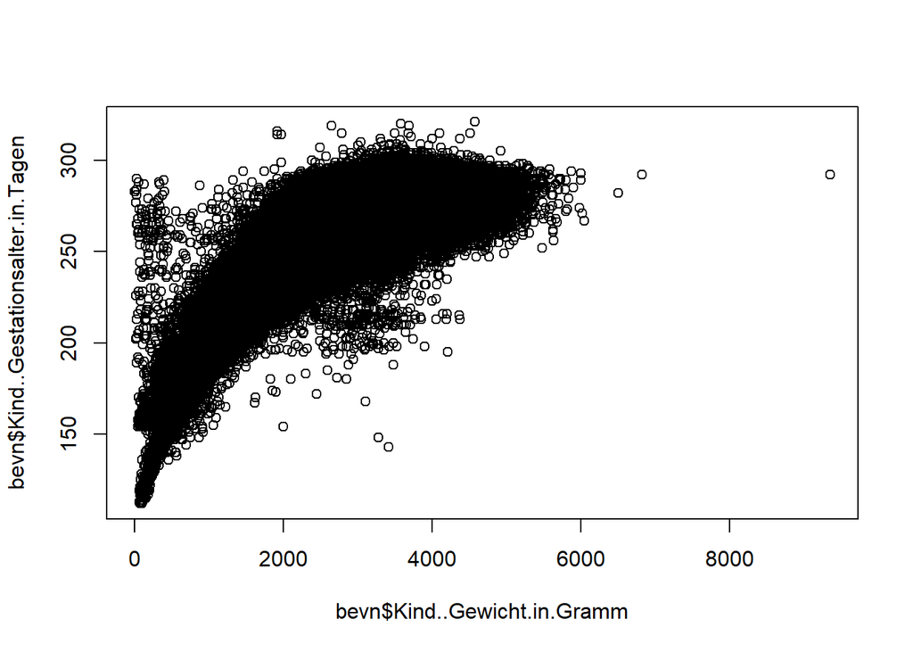

```r
plot(bevn$Kind..Gewicht.in.Gramm,bevn$Kind..Gestationsalter.in.Tagen) #BW and GA
```

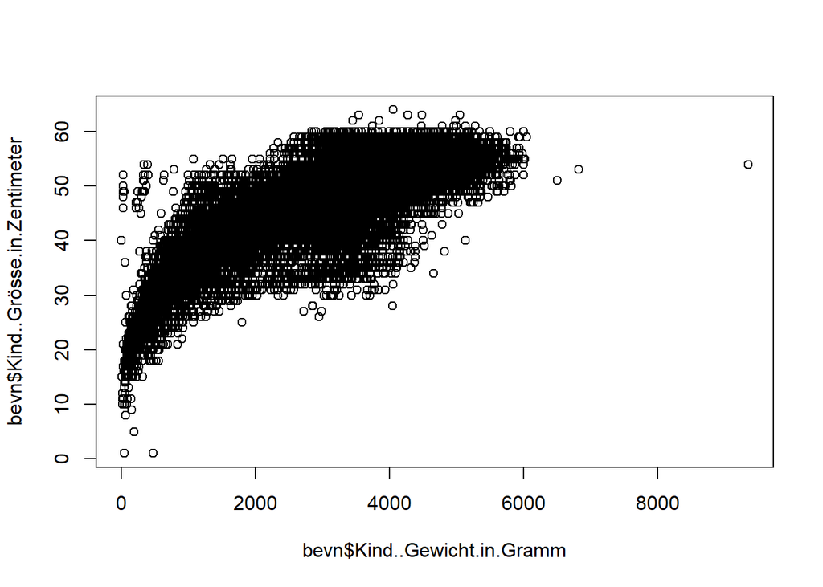

```r
plot(bevn$Kind..Gewicht.in.Gramm,bevn$Kind..Grösse.in.Zentimeter) #BW and BL
```

## Birthweight through the years

```r
BW_median2 <- aggregate(Kind..Gewicht.in.Gramm ~ Ereignisjahr, data = bevn, median)
BW_median2
```

```
##    Ereignisjahr Kind..Gewicht.in.Gramm
## 1          1987                   3330
## 2          1988                   3340
## 3          1989                   3340
## 4          1990                   3340
## 5          1991                   3340
## 6          1992                   3350
## 7          1993                   3350
## 8          1994                   3350
## 9          1995                   3340
## 10         1996                   3340
## 11         1997                   3340
## 12         1998                   3330
## 13         1999                   3340
## 14         2000                   3340
```

[output cut: 20 more lines]

## Length through the years

```r
BL_median <- aggregate(Kind..Grösse.in.Zentimeter ~ Ereignisjahr, data = bevn, median)
BL_median
```

```
##    Ereignisjahr Kind..Grösse.in.Zentimeter
## 1          1987                         50
## 2          1988                         50
## 3          1989                         50
## 4          1990                         50
## 5          1991                         50
## 6          1992                         50
## 7          1993                         50
## 8          1994                         50
## 9          1995                         50
## 10         1996                         50
## 11         1997                         50
## 12         1998                         50
## 13         1999                         50
## 14         2000                         50
```

[output cut: 20 more lines]

## Sex % through the years

```r
table(bevn$Kind..Geschlecht, bevn$Ereignisjahr)
```

```
##
##      1987  1988  1989  1990  1991  1992  1993  1994  1995  1996  1997  1998
##   F 38142 39937 40362 42077 43101 43622 41748 41275 41009 41158 40143 39476
##   M 39998 42125 42678 44046 45679 45668 44101 43572 43048 43600 42215 41437
##
##      1999  2000  2001  2002  2003  2004  2005  2006  2007  2008  2009  2010
##   F 38988 39046 36845 36969 37303 38776 40307 41004 41944 42804 43618 45334
##   M 41182 41492 38982 39284 39363 40563 42782 43604 43949 45494 46479 47457
##
##      2011  2012  2013  2014  2015  2016  2017  2018  2019  2020
##   F 44866 45622 46181 47379 47808 49017 48223 48372 47241 46366
##   M 47458 48754 48829 50117 50880 51336 50827 50820 49801 49302
```

```r
 round(prop.table(table(bevn$Kind..Geschlecht, bevn$Ereignisjahr), margin=2)*100,2)
```

```
##
##      1987  1988  1989  1990  1991  1992  1993  1994  1995  1996  1997  1998
##   F 48.81 48.67 48.61 48.86 48.55 48.85 48.63 48.65 48.79 48.56 48.74 48.79
##   M 51.19 51.33 51.39 51.14 51.45 51.15 51.37 51.35 51.21 51.44 51.26 51.21
##
##      1999  2000  2001  2002  2003  2004  2005  2006  2007  2008  2009  2010
##   F 48.63 48.48 48.59 48.48 48.66 48.87 48.51 48.46 48.83 48.48 48.41 48.86
##   M 51.37 51.52 51.41 51.52 51.34 51.13 51.49 51.54 51.17 51.52 51.59 51.14
##
##      2011  2012  2013  2014  2015  2016  2017  2018  2019  2020
##   F 48.60 48.34 48.61 48.60 48.44 48.84 48.69 48.77 48.68 48.47
##   M 51.40 51.66 51.39 51.40 51.56 51.16 51.31 51.23 51.32 51.53
```

## Stillbirth % through the years

```r
table(bevn$lebend.geboren.oder.nicht, bevn$Ereignisjahr)
```

```
##
##      1987  1988  1989  1990  1991  1992  1993  1994  1995  1996  1997  1998
##   1 77792 81736 82688 85718 88402 88938 85493 84551 83713 84440 82009 80599
##   2   348   326   352   405   378   352   356   296   344   318   349   314
##
##      1999  2000  2001  2002  2003  2004  2005  2006  2007  2008  2009  2010
##   1 79889 80244 75542 75997 76351 79059 82764 84253 85580 87932 89725 92421
##   2   281   294   285   256   315   280   325   355   313   366   372   370
##
##      2011  2012  2013  2014  2015  2016  2017  2018  2019  2020
##   1 91958 93990 94594 97107 98310 99955 98676 98789 96684 95339
##   2   366   386   416   389   378   398   374   403   358   329
```

```r
 round(prop.table(table(bevn$lebend.geboren.oder.nicht, bevn$Ereignisjahr), margin = 2)*100,2)
```

```
##
##      1987  1988  1989  1990  1991  1992  1993  1994  1995  1996  1997  1998
##   1 99.55 99.60 99.58 99.53 99.57 99.61 99.59 99.65 99.59 99.62 99.58 99.61
##   2  0.45  0.40  0.42  0.47  0.43  0.39  0.41  0.35  0.41  0.38  0.42  0.39
##
##      1999  2000  2001  2002  2003  2004  2005  2006  2007  2008  2009  2010
##   1 99.65 99.63 99.62 99.66 99.59 99.65 99.61 99.58 99.64 99.59 99.59 99.60
##   2  0.35  0.37  0.38  0.34  0.41  0.35  0.39  0.42  0.36  0.41  0.41  0.40
##
##      2011  2012  2013  2014  2015  2016  2017  2018  2019  2020
##   1 99.60 99.59 99.56 99.60 99.62 99.60 99.62 99.59 99.63 99.66
##   2  0.40  0.41  0.44  0.40  0.38  0.40  0.38  0.41  0.37  0.34
```

## Age of the mother through the years

```r
AM_median <- aggregate(Mutter..Alter.in.erfüllten.Jahren ~ Ereignisjahr, data = bevn, median)
AM_median
```

```
##    Ereignisjahr Mutter..Alter.in.erfüllten.Jahren
## 1          1987                                28
## 2          1988                                28
## 3          1989                                28
## 4          1990                                28
## 5          1991                                28
## 6          1992                                28
## 7          1993                                29
## 8          1994                                29
## 9          1995                                29
## 10         1996                                29
## 11         1997                                30
## 12         1998                                30
## 13         1999                                30
## 14         2000                                30
```

[output cut: 20 more lines]

## Creating a variable combining month+year of birth

```r
bevn$birthdate3 <- with(bevn, sprintf("%d-%02d", Ereignisjahr, Ereignismonat))
tail(bevn$birthdate3)
```

```
## [1] "2020-12" "2020-12" "2020-12" "2020-12" "2020-12" "2020-12"
```

## Birthweight change through the years: Simple model

```r
##boxplot(bevn$Ereignisjahr, bevn$Kind..Gewicht.in.Gramm) ##doesnt work
BW_years <- lm(Kind..Gewicht.in.Gramm~Ereignisjahr, data=bevn)
summary(BW_years)
```

```
##
## Call:
## lm(formula = Kind..Gewicht.in.Gramm ~ Ereignisjahr, data = bevn)
##
## Residuals:
##     Min      1Q  Median      3Q     Max
## -3277.4  -288.8    32.5   345.3  6070.6
##
## Coefficients:
##               Estimate Std. Error t value Pr(>|t|)
## (Intercept)  5860.3264    66.3249   88.36   <2e-16 ***
## Ereignisjahr   -1.2785     0.0331  -38.62   <2e-16 ***
## ---
## Signif. codes:  0 '***' 0.001 '**' 0.01 '*' 0.05 '.' 0.1 ' ' 1
##
## Residual standard error: 554.6 on 2821506 degrees of freedom
##   (151477 observations deleted due to missingness)
## Multiple R-squared:  0.0005284,  Adjusted R-squared:  0.0005281
## F-statistic:  1492 on 1 and 2821506 DF,  p-value: < 2.2e-16
```

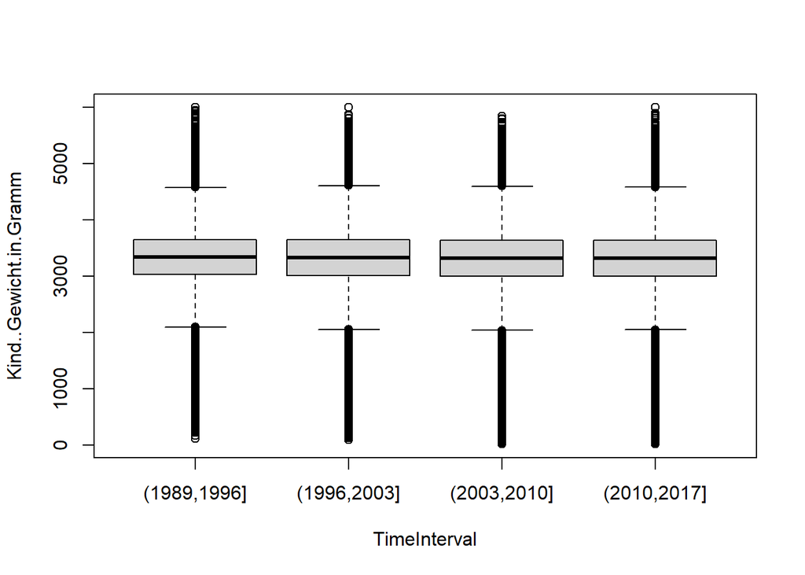

```r
library(ggplot2)
##ggplot(bevn, aes(x=Ereignisjahr, y=Kind..Gewicht.in.Gramm)) ##doesnt work

bevn$TimeInterval <- cut(bevn$Ereignisjahr, breaks=c(1989, 1996, 2003, 2010, 2017))
boxplot(Kind..Gewicht.in.Gramm~TimeInterval, data=bevn)
```

```r
meanBW <- mean(bevn$Kind..Gewicht.in.Gramm)
##ggplot(bevn, aes(x=Ereignisjahr, y=meanBW)) ##doesnt work
```